# Permutation tests and Power analysis

Dan MacLean

07/07/2020

## Permutation tests

### Load the data

```r
library(MKinfer)
library(readxl)

df <- read_excel("../data/Thor_3rd revision_raw data_Extended Data Figure 9.xlsx", sheet = 'Ext Data Fig 9b', range = "F5:G34")

df
```

```
## # A tibble: 29 x 2
##    `Col-0` `osca1.3/1.7`
##      <dbl>         <dbl>
##  1 2731.           1514.
##  2 -543.            557.
##  3 6348.           -230.
##  4 -932.           3838.
##  5 3080.            737.
##  6 1368.           3614.
##  7 2465.           4879.
##  8   -5.05         4099.
##  9 3171.           1786.
## 10 2761.           1943.
## # … with 19 more rows
```

```r
col <- na.omit(df$`Col-0`)
osca <- na.omit(df$`osca1.3/1.7`)
```

### Perform permutation $t$-tests and bootstrap $t$-tests

```r
perm.t.test(col, osca, alternative = "greater")
```

```
##
##  Permutation Welch Two Sample t-test
##
## data:  col and osca
## (Monte-Carlo) permutation p-value = 0.0362
## 95 percent (Monte-Carlo) permutation percentile confidence interval:
##  95.1863     Inf
##
## Results without permutation:
## t = 1.8091, df = 45.796, p-value = 0.0385
## alternative hypothesis: true difference in means is greater than 0
## 95 percent confidence interval:
##  99.90788      Inf
## sample estimates:
## mean of x mean of y
##  2818.491  1431.097
```

```r
boot.t.test(col,osca, alternative = "greater")
```

```
##
##  Bootstrapped Welch Two Sample t-test
##
## data:  col and osca
## bootstrapped p-value = 0.0448
## 95 percent bootstrap percentile confidence interval:
##  135.6862      Inf
##
## Results without bootstrap:
## t = 1.8091, df = 45.796, p-value = 0.0385
## alternative hypothesis: true difference in means is greater than 0
## 95 percent confidence interval:
##  99.90788      Inf
## sample estimates:
## mean of x mean of y
##  2818.491  1431.097
```

We observe the $p$-value for permuted and bootstrapped data to remain at a less than 0.05 significance level and conclude that the differences observed in the original Welch Two Sample $t$-test are not due to just a few data points.

### Variance distribution of permutations

The objective here is to see whether the observed variance for `col` and `osca` match the resampled versions.

We’ll generate a distribution of 10000 samples from the data and draw the density plot of the variance of the samples, then overlay the observed `col` and `osca` variances.

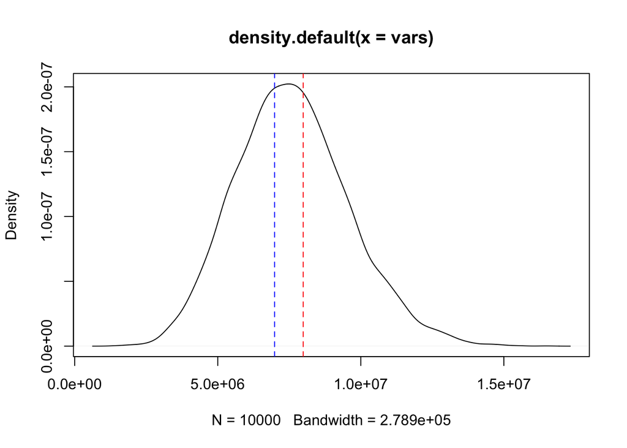

```r
library(gtools)
all <- c(col, osca)
samples <- lapply(1:10000, function(x) sample(all, size = length(osca), replace = TRUE) )
vars <- lapply(samples, function(s) sd(s) ^ 2)
vars <- unlist(vars)

plot(density(vars))
abline(v = sd(osca) ^ 2, lty="dashed", col="red")
abline(v = sd(col) ^ 2, lty="dashed", col="blue")
```